# Paras_Rupani-8961758_1_Lab3

## Importing Required Libraries for the NoteBook

```python
import pandas as pd
import matplotlib.pyplot as plt
from matplotlib.patches import Patch
import seaborn as sns

# Classifier Libraries
from sklearn.linear_model import LogisticRegression
from sklearn.model_selection import cross_val_score
from sklearn.preprocessing import StandardScaler, RobustScaler
from sklearn.svm import SVC
from sklearn.neighbors import KNeighborsClassifier

# Other Libraries
from sklearn.model_selection import train_test_split
from sklearn.metrics import precision_score, recall_score, f1_score, roc_auc_score, accuracy_score, classification_report
from sklearn.metrics import roc_curve, auc

import warnings
warnings.filterwarnings("ignore")
```

### Reading the Dataset

```python
df = pd.read_csv("./creditcard.csv")
df
```

|  | Time | V1 | V2 | V3 | V4 | V5 | V6 | V7 | V8 | V9 | ... | V21 | V22 | V23 | V24 | V25 | V26 | V27 | V28 | Amount | Class |
| --- | --- | --- | --- | --- | --- | --- | --- | --- | --- | --- | --- | --- | --- | --- | --- | --- | --- | --- | --- | --- | --- |
| 0 | 0.0 | -1.359807 | -0.072781 | 2.536347 | 1.378155 | -0.338321 | 0.462388 | 0.239599 | 0.098698 | 0.363787 | ... | -0.018307 | 0.277838 | -0.110474 | 0.066928 | 0.128539 | -0.189115 | 0.133558 | -0.021053 | 149.62 | 0 |
| 1 | 0.0 | 1.191857 | 0.266151 | 0.166480 | 0.448154 | 0.060018 | -0.082361 | -0.078803 | 0.085102 | -0.255425 | ... | -0.225775 | -0.638672 | 0.101288 | -0.339846 | 0.167170 | 0.125895 | -0.008983 | 0.014724 | 2.69 | 0 |
| 2 | 1.0 | -1.358354 | -1.340163 | 1.773209 | 0.379780 | -0.503198 | 1.800499 | 0.791461 | 0.247676 | -1.514654 | ... | 0.247998 | 0.771679 | 0.909412 | -0.689281 | -0.327642 | -0.139097 | -0.055353 | -0.059752 | 378.66 | 0 |
| 3 | 1.0 | -0.966272 | -0.185226 | 1.792993 | -0.863291 | -0.010309 | 1.247203 | 0.237609 | 0.377436 | -1.387024 | ... | -0.108300 | 0.005274 | -0.190321 | -1.175575 | 0.647376 | -0.221929 | 0.062723 | 0.061458 | 123.50 | 0 |
| 4 | 2.0 | -1.158233 | 0.877737 | 1.548718 | 0.403034 | -0.407193 | 0.095921 | 0.592941 | -0.270533 | 0.817739 | ... | -0.009431 | 0.798278 | -0.137458 | 0.141267 | -0.206010 | 0.502292 | 0.219422 | 0.215153 | 69.99 | 0 |
| ... | ... | ... | ... | ... | ... | ... | ... | ... | ... | ... | ... | ... | ... | ... | ... | ... | ... | ... | ... | ... | ... |
| 284802 | 172786.0 | -11.881118 | 10.071785 | -9.834783 | -2.066656 | -5.364473 | -2.606837 | -4.918215 | 7.305334 | 1.914428 | ... | 0.213454 | 0.111864 | 1.014480 | -0.509348 | 1.436807 | 0.250034 | 0.943651 | 0.823731 | 0.77 | 0 |
| 284803 | 172787.0 | -0.732789 | -0.055080 | 2.035030 | -0.738589 | 0.868229 | 1.058415 | 0.024330 | 0.294869 | 0.584800 | ... | 0.214205 | 0.924384 | 0.012463 | -1.016226 | -0.606624 | -0.395255 | 0.068472 | -0.053527 | 24.79 | 0 |
| 284804 | 172788.0 | 1.919565 | -0.301254 | -3.249640 | -0.557828 | 2.630515 | 3.031260 | -0.296827 | 0.708417 | 0.432454 | ... | 0.232045 | 0.578229 | -0.037501 | 0.640134 | 0.265745 | -0.087371 | 0.004455 | -0.026561 | 67.88 | 0 |
| 284805 | 172788.0 | -0.240440 | 0.530483 | 0.702510 | 0.689799 | -0.377961 | 0.623708 | -0.686180 | 0.679145 | 0.392087 | ... | 0.265245 | 0.800049 | -0.163298 | 0.123205 | -0.569159 | 0.546668 | 0.108821 | 0.104533 | 10.00 | 0 |
| 284806 | 172792.0 | -0.533413 | -0.189733 | 0.703337 | -0.506271 | -0.012546 | -0.649617 | 1.577006 | -0.414650 | 0.486180 | ... | 0.261057 | 0.643078 | 0.376777 | 0.008797 | -0.473649 | -0.818267 | -0.002415 | 0.013649 | 217.00 | 0 |

284807 rows × 31 columns

```python
df.describe()
```

|  | Time | V1 | V2 | V3 | V4 | V5 | V6 | V7 | V8 | V9 | ... | V21 | V22 | V23 | V24 | V25 | V26 | V27 | V28 | Amount | Class |
| --- | --- | --- | --- | --- | --- | --- | --- | --- | --- | --- | --- | --- | --- | --- | --- | --- | --- | --- | --- | --- | --- |
| count | 284807.000000 | 2.848070e+05 | 2.848070e+05 | 2.848070e+05 | 2.848070e+05 | 2.848070e+05 | 2.848070e+05 | 2.848070e+05 | 2.848070e+05 | 2.848070e+05 | ... | 2.848070e+05 | 2.848070e+05 | 2.848070e+05 | 2.848070e+05 | 2.848070e+05 | 2.848070e+05 | 2.848070e+05 | 2.848070e+05 | 284807.000000 | 284807.000000 |
| mean | 94813.859575 | 1.168375e-15 | 3.416908e-16 | -1.379537e-15 | 2.074095e-15 | 9.604066e-16 | 1.487313e-15 | -5.556467e-16 | 1.213481e-16 | -2.406331e-15 | ... | 1.654067e-16 | -3.568593e-16 | 2.578648e-16 | 4.473266e-15 | 5.340915e-16 | 1.683437e-15 | -3.660091e-16 | -1.227390e-16 | 88.349619 | 0.001727 |
| std | 47488.145955 | 1.958696e+00 | 1.651309e+00 | 1.516255e+00 | 1.415869e+00 | 1.380247e+00 | 1.332271e+00 | 1.237094e+00 | 1.194353e+00 | 1.098632e+00 | ... | 7.345240e-01 | 7.257016e-01 | 6.244603e-01 | 6.056471e-01 | 5.212781e-01 | 4.822270e-01 | 4.036325e-01 | 3.300833e-01 | 250.120109 | 0.041527 |
| min | 0.000000 | -5.640751e+01 | -7.271573e+01 | -4.832559e+01 | -5.683171e+00 | -1.137433e+02 | -2.616051e+01 | -4.355724e+01 | -7.321672e+01 | -1.343407e+01 | ... | -3.483038e+01 | -1.093314e+01 | -4.480774e+01 | -2.836627e+00 | -1.029540e+01 | -2.604551e+00 | -2.256568e+01 | -1.543008e+01 | 0.000000 | 0.000000 |
| 25% | 54201.500000 | -9.203734e-01 | -5.985499e-01 | -8.903648e-01 | -8.486401e-01 | -6.915971e-01 | -7.682956e-01 | -5.540759e-01 | -2.086297e-01 | -6.430976e-01 | ... | -2.283949e-01 | -5.423504e-01 | -1.618463e-01 | -3.545861e-01 | -3.171451e-01 | -3.269839e-01 | -7.083953e-02 | -5.295979e-02 | 5.600000 | 0.000000 |
| 50% | 84692.000000 | 1.810880e-02 | 6.548556e-02 | 1.798463e-01 | -1.984653e-02 | -5.433583e-02 | -2.741871e-01 | 4.010308e-02 | 2.235804e-02 | -5.142873e-02 | ... | -2.945017e-02 | 6.781943e-03 | -1.119293e-02 | 4.097606e-02 | 1.659350e-02 | -5.213911e-02 | 1.342146e-03 | 1.124383e-02 | 22.000000 | 0.000000 |
| 75% | 139320.500000 | 1.315642e+00 | 8.037239e-01 | 1.027196e+00 | 7.433413e-01 | 6.119264e-01 | 3.985649e-01 | 5.704361e-01 | 3.273459e-01 | 5.971390e-01 | ... | 1.863772e-01 | 5.285536e-01 | 1.476421e-01 | 4.395266e-01 | 3.507156e-01 | 2.409522e-01 | 9.104512e-02 | 7.827995e-02 | 77.165000 | 0.000000 |
| max | 172792.000000 | 2.454930e+00 | 2.205773e+01 | 9.382558e+00 | 1.687534e+01 | 3.480167e+01 | 7.330163e+01 | 1.205895e+02 | 2.000721e+01 | 1.559499e+01 | ... | 2.720284e+01 | 1.050309e+01 | 2.252841e+01 | 4.584549e+00 | 7.519589e+00 | 3.517346e+00 | 3.161220e+01 | 3.384781e+01 | 25691.160000 | 1.000000 |

8 rows × 31 columns

- We can see that the Time, Amount features are exponentially high when compared to the rest of the columns.
- Rest of the numerical features appear to be normalized already.
- Hence there is a need to normalize the columns: time and amount according to the other numerical features.

## Analyzing the Distribution of the Dataset

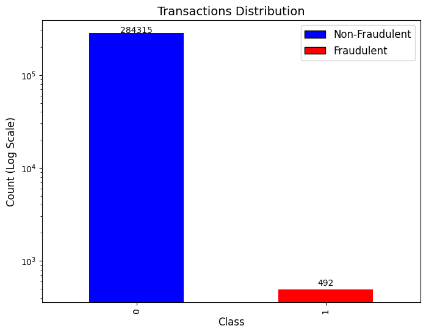

```python
import matplotlib.pyplot as plt
from matplotlib.patches import Patch

# Calculate the class counts
class_counts = df['Class'].value_counts()

# Create a bar chart
plt.figure(figsize=(8, 6))
bars = class_counts.plot(kind='bar', color=['blue', 'red'])

# Add count numbers on top of each bar
for i, count in enumerate(class_counts):
    plt.text(i, count + 50, str(count), ha='center', fontsize=10)

# Add title and labels
plt.title('Transactions Distribution', fontsize=14)
plt.xlabel('Class', fontsize=12)
plt.ylabel('Count (Log Scale)', fontsize=12)

# Create legend elements
legend_elements = [
    Patch(facecolor='blue', edgecolor='black', label='Non-Fraudulent'),
    Patch(facecolor='red', edgecolor='black', label='Fraudulent')
]

# Add legend
plt.legend(handles=legend_elements, fontsize=12)

# Set y-axis to log scale for better visualization
plt.yscale('log')

# Show plot
plt.show()
```

**Conclusion**: The dataset presents a significant class imbalance, with the majority of transactions being non-fraudulent. Further exploration reveals potential insights:

- The data mostly contains regular transactions, but there are only a few instances of fraudulent ones (just 492 out of many).
- We can study transaction amounts, time patterns, and important features to help spot fraud. It's important to check how well our detection methods work to accurately identify fraud.

Reference Used: [Kaggle- Outlier detection methods!](https://www.kaggle.com/code/marcinrutecki/outlier-detection-methods)

## Handling Outliers

```python
import pandas as pd
import numpy as np
from collections import Counter

def IQR_method(df, n, features):
    outlier_list = []

    for column in features:

        # 1st quartile (25%)
        Q1 = np.percentile(df[column], 25)
        # 3rd quartile (75%)
        Q3 = np.percentile(df[column],75)

        # Interquartile range (IQR)
        IQR = Q3 - Q1

        # outlier step
        outlier_step = 1.5 * IQR

        # Determining a list of indices of outliers
        outlier_list_column = df[(df[column] < Q1 - outlier_step) | (df[column] > Q3 + outlier_step )].index

        # appending the list of outliers
        outlier_list.extend(outlier_list_column)

    # selecting observations containing more than x outliers
    outlier_list = Counter(outlier_list)
    multiple_outliers = list(k for k, v in outlier_list.items() if v > n)

    # Calculate the number of records below and above lower and above bound value respectively
    df1 = df[df[column] < Q1 - outlier_step]
    df2 = df[df[column] > Q3 + outlier_step]

    print('Total number of outliers is:', df1.shape[0]+df2.shape[0])

    return multiple_outliers

# Read the dataset
df = pd.read_csv("./creditcard.csv")

# Define features (columns) to check for outliers
feature_list = df.columns.tolist()

# Remove the 'Time' and 'Class' columns from the feature list
feature_list.remove('Time')
feature_list.remove('Class')

# detecting outliers
Outliers_IQR = IQR_method(df, 1, feature_list)

# dropping outliers
df_out = df.drop(Outliers_IQR, axis=0).reset_index(drop=True)
```

```
Total number of outliers is: 31904
```

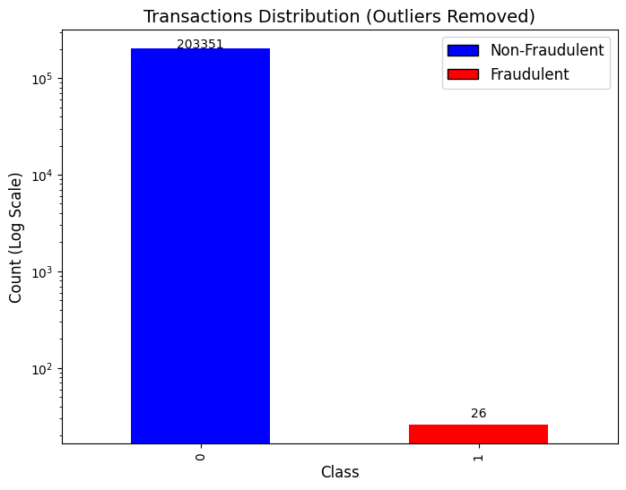

```python
import matplotlib.pyplot as plt
from matplotlib.patches import Patch

# Calculate the class counts after removing outliers
class_counts = df_out['Class'].value_counts()

# Create a bar chart
plt.figure(figsize=(8, 6))
bars = class_counts.plot(kind='bar', color=['blue', 'red'])

# Add count numbers on top of each bar
for i, count in enumerate(class_counts):
    plt.text(i, count + 5, str(count), ha='center', fontsize=10)

# Add title and labels
plt.title('Transactions Distribution (Outliers Removed)', fontsize=14)
plt.xlabel('Class', fontsize=12)
plt.ylabel('Count (Log Scale)', fontsize=12)

# Create legend elements
legend_elements = [
    Patch(facecolor='blue', edgecolor='black', label='Non-Fraudulent'),
    Patch(facecolor='red', edgecolor='black', label='Fraudulent')
]

# Add legend
plt.legend(handles=legend_elements, fontsize=12)

# Set y-axis to log scale for better visualization
plt.yscale('log')

# Show plot
plt.show()
```

- As we see that the after removing the outliers, a significant amount of the fraudulent transactions are removed from the dataset, which is the primary motive of the model's prediction.
- When we remove these transactions, the amount of data which the model is trained on reduces affecting the accuracy and efficiency of the model.

**Conclusion:** Dropping these outliers is not the perfect way to handle the data, as we are worsening the model, by removing valuable data from the dataset.

### Distributing Amount and Time for Transactions

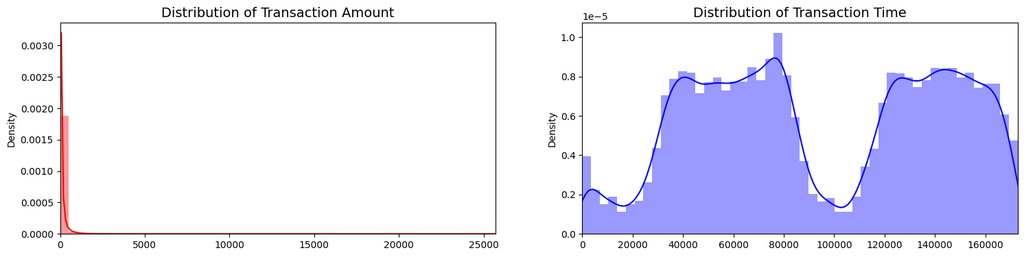

```python
fig, ax = plt.subplots(1, 2, figsize=(18,4))

amount_val = df['Amount'].values
time_val = df['Time'].values

sns.distplot(amount_val, ax=ax[0], color='r')
ax[0].set_title('Distribution of Transaction Amount', fontsize=14)
ax[0].set_xlim([min(amount_val), max(amount_val)])

sns.distplot(time_val, ax=ax[1], color='b')
ax[1].set_title('Distribution of Transaction Time', fontsize=14)
ax[1].set_xlim([min(time_val), max(time_val)])



plt.show()
```

- We can see that majority of the transaction amounts lie between the amount of 0 - 2000.
- We observe that the time is evenly spread except at around the 20,000 and 100,000 intervals.

## Normalizing Numerical Features

```python
# RobustScaler is less prone to outliers.
rob_scaler = RobustScaler()

df['Scaled_Amount'] = rob_scaler.fit_transform(df['Amount'].values.reshape(-1,1))
df['Scaled_Time'] = rob_scaler.fit_transform(df['Time'].values.reshape(-1,1))
```

```python
df.drop(['Time','Amount'], axis=1, inplace=True)
```

```python
scaled_amount = df['Scaled_Amount']
scaled_time = df['Scaled_Time']
transaction_type = df['Class']

df.drop(['Scaled_Amount', 'Scaled_Time', 'Class'], axis=1, inplace=True)
df.insert(0, 'Scaled_Amount', scaled_amount)
df.insert(1, 'Scaled_Time', scaled_time)
df.insert(2, 'Class', transaction_type)
```

```python
df.head()
```

[output not shown]

5 rows × 31 columns

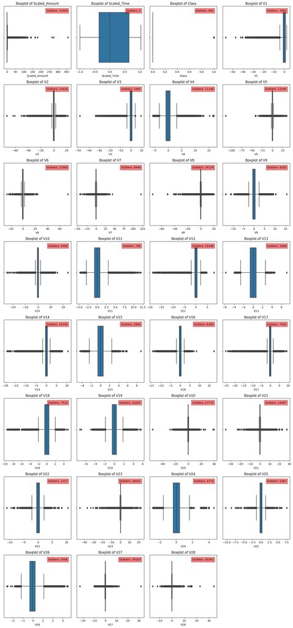

```python
# Calculate Q1 (25th percentile) for each column
Q1 = df.quantile(0.25)

# Calculate Q3 (75th percentile) for each column
Q3 = df.quantile(0.75)

# Calculate IQR for each column
IQR = Q3 - Q1

# Calculate lower and upper bounds for outliers for each column
lower_bound = Q1 - 1.5 * IQR
upper_bound = Q3 + 1.5 * IQR

# Identify outliers for each column
outliers = ((df < lower_bound) | (df > upper_bound))

# Count the number of outliers for each column
num_outliers = outliers.sum()

# Plot four boxplots in a row for each numerical feature
numerical_columns = df.select_dtypes(include=['float64', 'int64']).columns
num_plots = len(numerical_columns)
num_cols = 4
num_rows = (num_plots + num_cols - 1) // num_cols

fig, axes = plt.subplots(num_rows, num_cols, figsize=(15, 4*num_rows))
for i, column in enumerate(numerical_columns):
    row = i // num_cols
    col = i % num_cols
    ax = axes[row, col]
    sns.boxplot(x=df[column], ax=ax)
    ax.set_title(f'Boxplot of {column}')

    # Add text annotation for number of outliers
    num_out = num_outliers[column]
    ax.text(0.95, 0.95, f'Outliers: {num_out}', verticalalignment='top', horizontalalignment='right',
            transform=ax.transAxes, fontsize=10, bbox=dict(facecolor='red', alpha=0.5))

# Hide empty subplots if the number of plots is not a multiple of 4
if num_plots % num_cols != 0:
    for i in range(num_plots % num_cols, num_cols):
        fig.delaxes(axes[-1, i])

plt.tight_layout()
plt.show()
```

```python
anomaly_rows = df[df["Class"] == 1]
regular_rows = df[df["Class"] == 0]

print(f"Regular Transactions: {len(regular_rows)} ({round(df['Class'].value_counts()[0]/len(df) * 100,2)}%)")
print(f"Fraudulent Transactions: {len(anomaly_rows)} ({round(df['Class'].value_counts()[1]/len(df) * 100,2)}%)")
```

```
Regular Transactions: 284315 (99.83%)
Fraudulent Transactions: 492 (0.17%)
```

We can see that the dataset is completely imbalanced and we have majority of the transactions which are normal, and a fraction of fraudulent transactions which might look like outliers if they are handled carelessly.

There are high chances for the model, if it is trained on the current dataset, it will overfit and consider the fraudulent transactions as normals.

## Analyzing Correlations

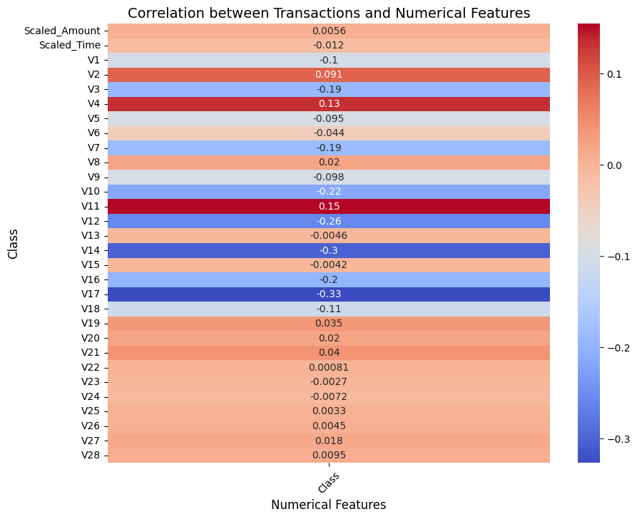

```python
# Compute the correlation matrix
correlation_matrix = df.corr()

# Extract correlations between 'Class' and other numerical features
class_correlations = correlation_matrix['Class'].drop('Class')

# Plot heatmap
plt.figure(figsize=(10, 8))
sns.heatmap(class_correlations.to_frame(), annot=True, cmap='coolwarm', cbar=True)
plt.title('Correlation between Transactions and Numerical Features', fontsize=14)
plt.xlabel('Numerical Features', fontsize=12)
plt.ylabel('Class', fontsize=12)
plt.xticks(rotation=45)
plt.show()
```

Highest Positive Correlation:

- We can see that V11, followed by V4, V2.

Highest Negative Correlation:

- We can analyze that V17, followed by V14, V12.

Highest Correlation: V17 (-0.33)

## Top 10 Correlations

```python
# Sort correlations in descending order
top_correlations = class_correlations.abs().sort_values(ascending=False)

# Select the top 10 correlated features
top_10_features = top_correlations.head(10)

print("Top 10 correlated numerical features with 'Class':")
print(top_10_features)
```

```
Top 10 correlated numerical features with 'Class':
V17    0.326481
V14    0.302544
V12    0.260593
V10    0.216883
V16    0.196539
V3     0.192961
V7     0.187257
V11    0.154876
V4     0.133447
V18    0.111485
Name: Class, dtype: float64
```

Highest Correlation: V17 (0.326)

## Plotting the Top 10 Distributions

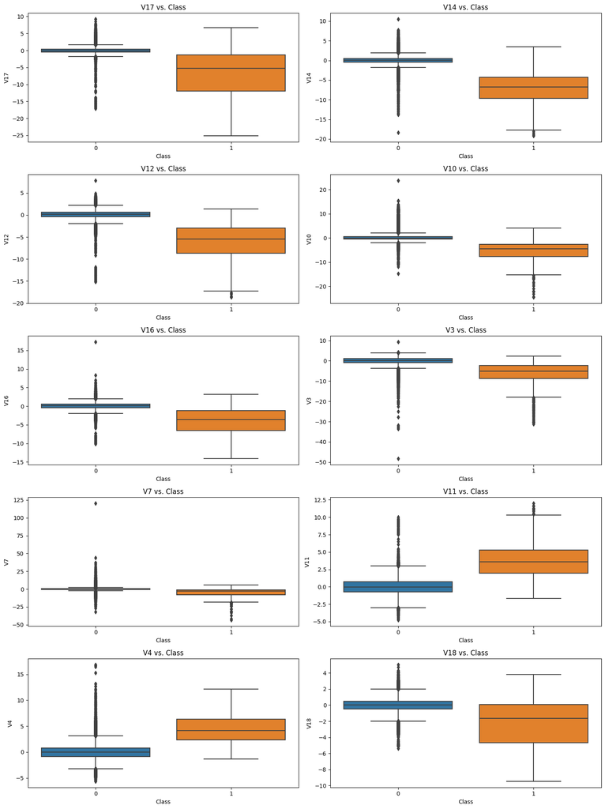

```python
# Select the top 10 correlated features
top_10_features_names = top_10_features.index.tolist()

# Plot the top 10 features against the 'Class' column
plt.figure(figsize=(15, 20))
for i, feature in enumerate(top_10_features_names):
    plt.subplot(5, 2, i + 1)
    sns.boxplot(x='Class', y=feature, data=df)
    plt.title(f'{feature} vs. Class')
    plt.xlabel('Class')
    plt.ylabel(feature)

plt.tight_layout()
plt.show()
```

## Splitting the Dataset into Train and Test

```python
X = df.drop('Class', axis=1)
y = df['Class']


X_train, X_test, y_train, y_test = train_test_split(X, y, test_size=0.2, random_state=42)

X_train = X_train.values
X_test = X_test.values
y_train = y_train.values
y_test = y_test.values
```

## Using 5 Fold Cross Validation

```python
classifiers = {
    "LogisiticRegression": LogisticRegression(),
    "KNearest": KNeighborsClassifier(),
    "Support Vector Classifier": SVC(),
}

for key, classifier in classifiers.items():
    classifier.fit(X_train, y_train)
    training_score = cross_val_score(classifier, X_train, y_train, cv=5)
    print("Classifiers: ", classifier.__class__.__name__, "Has a training score of", round(training_score.mean(), 2) * 100, "% accuracy score")
```

```
Classifiers:  LogisticRegression Has a training score of 100.0 % accuracy score
Classifiers:  KNeighborsClassifier Has a training score of 100.0 % accuracy score
Classifiers:  SVC Has a training score of 100.0 % accuracy score
```

### Analysis

- **Logistic Regression:**
  - **Training Score:** 100% accuracy
  - This indicates that the Logistic Regression model achieves perfect accuracy on the training data, suggesting that it fits the training data well without any errors.
- **K-Nearest Neighbors (KNN):**
  - **Training Score:** 100% accuracy
  - Similar to Logistic Regression, the KNN model also achieves perfect accuracy on the training data, indicating a good fit to the training data.
- **Support Vector Classifier (SVC):**
  - **Training Score:** 100% accuracy
  - The SVC model also achieves perfect accuracy on the training data, suggesting that it fits the training data well without errors.

**Conclusion:** All three classifiers demonstrate perfect accuracy on the training data, suggesting they fit the data well. However, it's essential to assess their performance on unseen data (e.g., using a separate test set) to determine their generalization capability. Additionally, perfect accuracy on the training data might indicate overfitting, so further evaluation on unseen data is crucial.

## Logistic Regression

```python
logreg_model = LogisticRegression()

# Train the model on the training data
logreg_model.fit(X_train, y_train)

# Make predictions on the testing data
y_pred = logreg_model.predict(X_test)

feature_names = X.columns

# Evaluate the model's performance
accuracy = accuracy_score(y_test, y_pred)
print("Accuracy:", accuracy)
```

```
Accuracy: 0.9991222218320986
```

## Learnt Coefficients and Weights

```python
# Create a DataFrame to store feature names and coefficients
coefficients_df = pd.DataFrame({'Feature': feature_names, 'Coefficient': logreg_model.coef_[0]})

# Print the DataFrame
print(coefficients_df)
```

```
          Feature  Coefficient
0   Scaled_Amount     0.066450
1     Scaled_Time    -0.588242
2              V1     0.130113
3              V2    -0.023235
4              V3    -0.050801
5              V4     0.658888
6              V5     0.136263
7              V6    -0.095766
8              V7    -0.121306
9              V8    -0.197533
10             V9    -0.280059
11            V10    -0.674366
12            V11    -0.122653
13            V12     0.040141
```

[output cut: 16 more lines]

## Model's Performance on Test Set

```python
# Generate classification report
report = classification_report(y_test, y_pred)

# Print the classification report
print("Classification Report:")
print(report)
```

```
Classification Report:
              precision    recall  f1-score   support

           0       1.00      1.00      1.00     56864
           1       0.86      0.58      0.70        98

    accuracy                           1.00     56962
   macro avg       0.93      0.79      0.85     56962
weighted avg       1.00      1.00      1.00     56962
```

**Observations:**

**Conclusion:**

The model excels in identifying non-fraudulent transactions but could benefit from enhancements to accurately detect fraudulent transactions.

## Highest Weight Feature

```python
max_coef_feature = coefficients_df.loc[coefficients_df['Coefficient'].abs().idxmax()]

# Print the feature with the highest coefficient
print("Feature with the highest coefficient:")
print("Feature:", max_coef_feature['Feature'])
print(f"Coefficient: {max_coef_feature['Coefficient']:.2f}")
```

```
Feature with the highest coefficient:
Feature: V27
Coefficient: -0.86
```

## ROC Curve and AUC Value

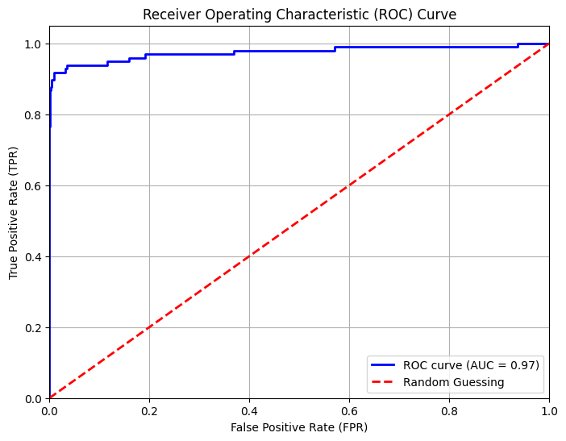

```
AUC: 0.9748921163851022
```

```python
# Compute ROC curve and AUC
fpr, tpr, thresholds = roc_curve(y_test, logreg_model.predict_proba(X_test)[:, 1])
roc_auc = auc(fpr, tpr)

# Plot ROC curve
plt.figure(figsize=(8, 6))
plt.plot(fpr, tpr, color='blue', lw=2, label='ROC curve (AUC = %0.2f)' % roc_auc)
plt.plot([0, 1], [0, 1], color='red', lw=2, linestyle='--', label='Random Guessing')
plt.xlim([0.0, 1.0])
plt.ylim([0.0, 1.05])
plt.xlabel('False Positive Rate (FPR)')
plt.ylabel('True Positive Rate (TPR)')
plt.title('Receiver Operating Characteristic (ROC) Curve')
plt.legend(loc='lower right')
plt.grid(True)
plt.show()

# Print AUC
print("AUC:", roc_auc)
```

**ROC Curve:**

- The picture shows an blue line, which represents the Receiver Operating Characteristic (ROC) curve.
- The ROC curve displays the true positive rate (TPR) against the false positive rate (FPR) for different thresholds of a classification model.
- It helps assess how well a binary classification model performs across different threshold settings.

**Analysis:**

**Conclusion:**

- The Area Under the Curve (AUC) for this ROC curve is around 0.97.
- An AUC close to 1 signifies excellent model performance.
- This classification model demonstrates high true positive rates and low false positive rates across various threshold settings, making it reliable for predicting classes effectively.

## Handling Class Imbalance

#### Reference Used: [Kaggle- Credit Fraud || Dealing with Imbalanced Datasets](https://www.kaggle.com/code/janiobachmann/credit-fraud-dealing-with-imbalanced-datasets)

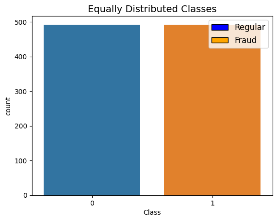

```python
# Lets shuffle the data before creating the subsamples

df = df.sample(frac=1, random_state=42)

df.head()

fraud_df = df.loc[df['Class'] == 1]
non_fraud_df = df.loc[df['Class'] == 0][:492]

normal_distributed_df = pd.concat([fraud_df, non_fraud_df])

# Shuffle dataframe rows
new_df = normal_distributed_df.sample(frac=1, random_state=42)

new_df.head()


# Plot countplot
sns.countplot(x='Class', data=new_df)

# Add title
plt.title('Equally Distributed Classes', fontsize=14)

# Manually specify legend labels and colors
legend_elements = [Patch(facecolor='blue', edgecolor='black', label='Regular'),
                   Patch(facecolor='orange', edgecolor='black', label='Fraud')]
plt.legend(handles=legend_elements, fontsize=12)

# Show plot
plt.show()
```

We can reformat the dataset with a 50/50 ratio of fraud and non-fraud transactions. Meaning our new dataset will have the same amount of fraud and regular transactions.

There are 492 cases of fraud in our dataset so we can randomly get 492 cases of non-fraud.

We concat the 984 cases of fraud and non fraud, creating a new sub-sample.

## KNN Model

```python
# Create KNN classifier
knn_clf = KNeighborsClassifier()

# Train the model on the training data
knn_clf.fit(X_train, y_train)

# Make predictions on the test set
y_pred_knn = knn_clf.predict(X_test)

# Evaluate the model's performance on the test set
accuracy_knn = accuracy_score(y_test, y_pred_knn)
print(f"Accuracy of KNN: {accuracy_knn:.2f}")
```

```
Accuracy of KNN: 1.00
```

## SVM Model

```python
# Create SVM classifier
svm_clf = SVC()

# Train the model on the training data
svm_clf.fit(X_train, y_train)

# Make predictions on the test set
y_pred_svm = svm_clf.predict(X_test)

# Evaluate the model's performance on the test set
accuracy_svm = accuracy_score(y_test, y_pred_svm)
print(f"Accuracy of SVM: {accuracy_svm:.2f}")
```

```
Accuracy of SVM: 1.00
```

# Comparing Performances of Models:

# Logistic Regression vs KNN vs SVM

```python
# Initialize lists to store evaluation metrics
accuracies = []
precisions = []
recalls = []
f1_scores = []

# Define models and their predictions
model_list = ['Logistic Regression', 'KNN', 'SVM']
pred_list = [y_pred, y_pred_knn, y_pred_svm]

# Evaluate each model
for model, pred in zip(model_list, pred_list):
    accuracies.append(accuracy_score(y_test, pred))
    precisions.append(precision_score(y_test, pred))
    recalls.append(recall_score(y_test, pred))
    f1_scores.append(f1_score(y_test, pred))

# Create a DataFrame to represent the data
df = pd.DataFrame({
    'Model': model_list,
    'Accuracy': accuracies,
    'Precision': precisions,
    'Recall': recalls,
    'F1 Score': f1_scores
})

(df)
```

|  | Model | Accuracy | Precision | Recall | F1 Score |
| --- | --- | --- | --- | --- | --- |
| 0 | Logistic Regression | 0.999122 | 0.863636 | 0.581633 | 0.695122 |
| 1 | KNN | 0.999491 | 0.948052 | 0.744898 | 0.834286 |
| 2 | SVM | 0.999386 | 0.970149 | 0.663265 | 0.787879 |

**Observations:**